# Feature Scaling

## Feature Scaling:

1. StandardScaler
2. MinMaxScaler
3. RobustScaler

## 1. Standard Scaler

The StandardScaler assumes your data is normally distributed within each feature and will scale them such that the distribution is now centred around 0, with a standard deviation of 1.

The mean and standard deviation are calculated for the feature and then the feature is scaled based on:

(xi–mean(x)) / stdev(x)

If data is not normally distributed, this is not the best scaler to use.

```python
import pandas as pd
import numpy as np
import seaborn as sns
import matplotlib
import matplotlib.pyplot as plt
%matplotlib inline
matplotlib.style.use('ggplot')
from sklearn.preprocessing import StandardScaler
```

```python
np.random.seed(101)
```

```python
df = pd.DataFrame({
    'x1': np.random.normal(0,2,1000),
    'x2': np.random.normal(5,3,1000),
    'x3': np.random.normal(-5,5,1000)
})
```

```python
df.head(5)
```

|  | x1 | x2 | x3 |
| --- | --- | --- | --- |
| 0 | 5.413700 | 6.954881 | -12.583504 |
| 1 | 1.256265 | 4.775656 | 0.836988 |
| 2 | 1.815939 | 3.846319 | -0.450725 |
| 3 | 1.007652 | 6.312765 | -5.332257 |
| 4 | 1.302236 | 3.472830 | -6.044324 |

```python
scaler = StandardScaler()
```

```python
scaled_df = scaler.fit_transform(df)
```

```python
scaled_df = pd.DataFrame(scaled_df,columns = ['x1','x2','x3'])
```

```python
scaled_df.head(5)
```

|  | x1 | x2 | x3 |
| --- | --- | --- | --- |
| 0 | 2.545735 | 0.587412 | -1.532272 |
| 1 | 0.571467 | -0.119803 | 1.096335 |
| 2 | 0.837243 | -0.421397 | 0.844117 |
| 3 | 0.453406 | 0.379028 | -0.112005 |
| 4 | 0.593297 | -0.542604 | -0.251474 |

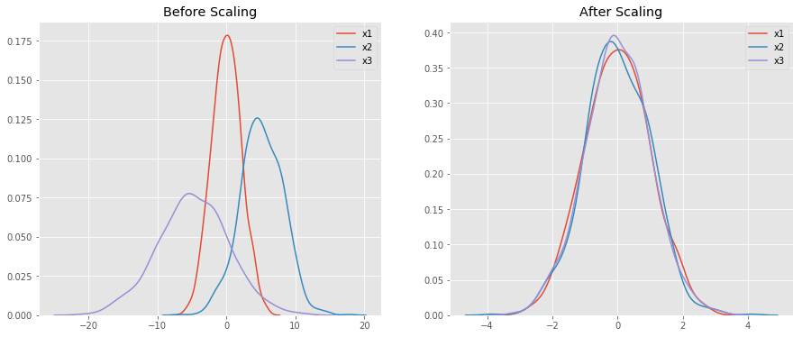

```python
fig, (plot1,plot2) = plt.subplots(ncols=2,figsize=(15,6))
plot1.set_title('Before Scaling')
plot2.set_title('After Scaling')
sns.kdeplot(df['x1'],ax=plot1)
sns.kdeplot(df['x2'],ax=plot1)
sns.kdeplot(df['x3'],ax=plot1)
sns.kdeplot(scaled_df['x1'],ax=plot2)
sns.kdeplot(scaled_df['x2'],ax=plot2)
sns.kdeplot(scaled_df['x3'],ax=plot2)
plt.show()
```

## 2. MinMaxScaler

The MinMaxScaler is one of the most famous scaling algorithm, and follows the following formula for each feature:

(xi–min(x)) / (max(x)–min(x))

It essentially shrinks the range such that the range is now between 0 and 1 (or -1 to 1 if there are negative values).

This scaler works better for cases in which the standard scaler might not work so well. If the distribution is not Gaussian or the standard deviation is very small, the min-max scaler works better.

However, it is sensitive to outliers, so if there are outliers in the data, you might want to consider the Robust Scaler below.

```python
df = pd.DataFrame({
    #positive skew
    'x1': np.random.chisquare(8, 1000),
    #negative skew
    'x2': np.random.beta(8,2,1000)*70,
    #no skew
    'x3': np.random.normal(50,3,1000)
})
```

```python
from sklearn.preprocessing import MinMaxScaler
```

```python
scaler = MinMaxScaler()
```

```python
scaled_df = scaler.fit_transform(df)
```

```python
scaled_df = pd.DataFrame(scaled_df,columns = ['x1','x2','x3'])
```

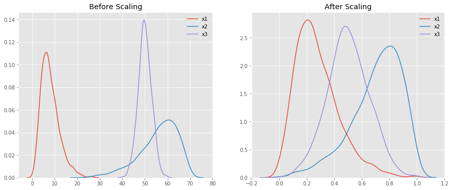

```python
fig2, (plot5,plot6) = plt.subplots(ncols=2,figsize=(15,6))
plot5.set_title("Before Scaling")
plot6.set_title("After Scaling")
sns.kdeplot(df['x1'],ax=plot5)
sns.kdeplot(df['x2'],ax=plot5)
sns.kdeplot(df['x3'],ax=plot5)
sns.kdeplot(scaled_df['x1'],ax=plot6)
sns.kdeplot(scaled_df['x2'],ax=plot6)
sns.kdeplot(scaled_df['x3'],ax=plot6)
plt.show()
```

Notice that the skewness of the distribution is maintained but the 3 distributions are brought into the same scale so that they overlap.

## 3. Robust Scaler

For each feature.

Of course this means it is using the less of the data for scaling so it’s more suitable for when there are outliers in the data.

Let’s take a look at this one in action on some data with outliers.

```python
df = pd.DataFrame({
    'x1': np.concatenate([np.random.normal(20,1,1000),np.random.normal(1,1,25)]),
    'x2': np.concatenate([np.random.normal(30,1,1000),np.random.normal(50,1,25)])
})
```

```python
from sklearn.preprocessing import RobustScaler
```

```python
scaler = RobustScaler()
```

```python
scaled_df = scaler.fit_transform(df)
```

```python
scaled_df = pd.DataFrame(scaled_df,columns=['x1','x2'])
```

```python
MnMxScaler = MinMaxScaler()
```

```python
MnMxdf = MnMxScaler.fit_transform(df)
```

```python
MnMxdf =pd.DataFrame(MnMxdf,columns=['x1','x2'])
```

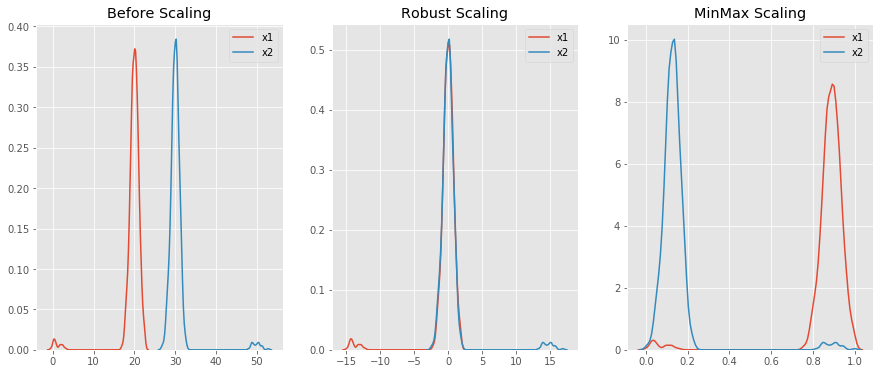

```python
fig, (ax1,ax2,ax3) = plt.subplots(ncols=3,figsize = (15,6))
ax1.set_title("Before Scaling")
ax2.set_title("Robust Scaling")
ax3.set_title("MinMax Scaling")
sns.kdeplot(df['x1'],ax=ax1)
sns.kdeplot(df['x2'],ax=ax1)
sns.kdeplot(scaled_df['x1'],ax=ax2)
sns.kdeplot(scaled_df['x2'],ax=ax2)
sns.kdeplot(MnMxdf['x1'],ax=ax3)
sns.kdeplot(MnMxdf['x2'],ax=ax3)
plt.show()
```

Notice that after Robust scaling, the distributions are brought into the same scale and overlap, but the outliers remain outside of bulk of the new distributions.

However, in Min-Max scaling, the two normal distributions are kept seperate by the outliers that are inside the 0-1 range.